# Fitting a STARMAGARCH model

Sondre Hølleland

2020-05-06

This vignette describes how to use the starmagarch packge to fit a STARMAGARCH($p,q,r,s$) model to data.

## Simulation

We start by simulating some data from a STARMAGARCH model. To do this, we must first specify the parameters and the neighbourhood system. The parameters should be a list containing the names `mu`, `phi`, `theta`, `omega`, `alpha`, `beta`, preferably in that order. The elements `mu` and `omega` are scalars (numeric), while the others should be matrices. The number of columns determines the maximum temporal lag and the number of rows the maximum spatial lag. These do not need to be equal for the differents parts of the model.

```r
parameters <- list(
  mu    = 5,
  phi   = matrix(c(.8, .1), ncol = 1), #temporal order 1, spatial order 2
  theta = matrix(c(-.42, -.2), ncol = 1),  #temporal order 1, spatial order 2
  omega = .9,
  alpha = matrix(c(.09, .13,
                   .03, .07), ncol = 2), # temporal order 2, spatial order 2
  beta  = matrix(c(.5, .15), ncol = 1) #temporal order 1, spatial order 2
)
sum(parameters$alpha,parameters$beta)
```

```
#> [1] 0.97
```

```r
# spatial dimension:
m <- c(25, 1)
library(starmagarch)
W <- create.neighbourhood.array(m = m, sp = 3, type = "rook", torus =TRUE)
```

Now, we are ready to simulate a process. There are two calls, either you can specify the neighbourhood array in advance (as we just did) or the simulation function can create it for the specific simulation. The the spatial order is calculated from the parameters given. The reason for allowing these two options is that if you are to simulate multiple samples from the same process, it will be faster to not recreate the neighbourhood system every time. In this case, `#1` is the faster, recommended option.

```r
set.seed(1234)
y <- simSTARMAGARCH(parameters, n = 2500, m = m, W=W, burnin = 500)   # 1
#y <- simSTARMAGARCH(parameters, n = 2500, m = m, burnin = 500,        # 2
                    #type= "rook", torus = TRUE)
```

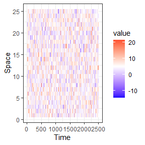

```r
library(ggplot2)
library(reshape2)
ggplot(data=melt(y), aes(Var2,Var1))+ geom_raster(aes(fill = value))+
  scale_fill_gradient2(low="blue", mid="white", high = "red", midpoint = mean(y)) + xlab("Time") + ylab("Space") +
  theme_bw()
```

## Estimation

To Estimate a process, we must specify initial parameters. This also gives the order of the model you want to fit. Here we specify the model with correct order, but set some conservative values.

```r
initial.parameters <- list(
  mu    = mean(y),
  phi   = matrix(c(.7, .01), ncol = 1),
  theta = matrix(c(.01, .01), ncol = 1),
  omega = 1,
  alpha = matrix(c(.01, .01,
                   .01, .01), ncol = 2),
  beta  = matrix(c(.01, .01), ncol = 1)
)
```

The next step is to build a likelihood object from the `TMB` package. We have created a template for STARMAGARCH and created a wrapper function that builds the model.

```r
# Create likelihood object:
# f <- CreateLikelihood(y, W=W,
#                  init = apply(y,1,var), parameters=initial.parameters)
# To save time, we use the true parameters as initial values:
f <- CreateLikelihood(y, W=W,
                 init = apply(y,1,var), parameters=parameters)
```

Here, `f` is a list of functions containing the likelihood, gradient and hessian functions found by automatic differentiation. The `init` argument allows the user to specify initial values for the $\{\sigma_0^2(u)\}$ process. This should be a non-negative vector of length `prod(m)`. The other necessary initial values are set to zero.

Optimizing the likelihood is done using the `nlminb` function. We have also here written a wrapper function to do this. This function also creates an object of the class `starmagarch`, with classical generic functions attached to it, such as `plot`, `plot_garch`, `summary`, `AIC`, `BIC`, `residuals`, `coef`, `sigma`, `fitted`, `fittedgarch`, etc.

```r
fit <- fitSTARMAGARCH(f, data = y, print = FALSE)
summary(fit)
```

```
#>          Estimates          SD     Zscore       Pvalue
#> mu      5.00004983 0.033729644 148.239033 0.000000e+00
#> phi1    0.79548858 0.005146813 154.559440 0.000000e+00
#> phi2    0.09597303 0.010490012   9.148992 2.873371e-20
#> theta1 -0.40707767 0.007883100 -51.639287 0.000000e+00
#> theta2 -0.19556408 0.016515565 -11.841198 1.195071e-32
#> omega   0.99618213 0.068672111  14.506357 5.521612e-48
#> alpha1  0.09763498 0.006235819  15.657123 1.485177e-55
#> alpha2  0.12370149 0.011649157  10.618921 1.216784e-26
#> alpha3  0.02903214 0.008239054   3.523723 2.127643e-04
#> alpha4  0.07772260 0.015201964   5.112668 1.588198e-07
#> beta1   0.49077839 0.035044774  14.004325 7.333365e-45
#> beta2   0.13670043 0.050217390   2.722173 3.242708e-03
#>
#>
#> Standardized residual standard error:  1 .
#>  AIC:  150034.7   BIC:  150143.2
```

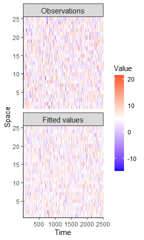

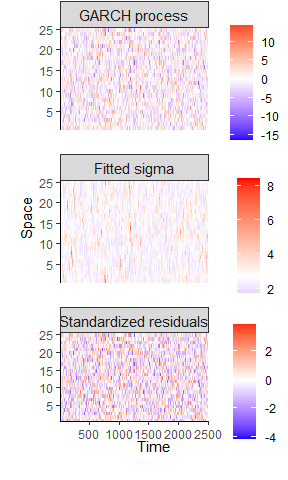

```r
plot(fit)
plot_garch(fit)
```

Comparing the results with the parameteres that generated the data:

```r
round(rbind(unlist(parameters), round(coef(fit),4)), 4)
```

```
#>      mu   phi1  phi2  theta1  theta2  omega alpha1 alpha2 alpha3 alpha4  beta1
#> [1,]  5 0.8000 0.100 -0.4200 -0.2000 0.9000 0.0900 0.1300  0.030 0.0700 0.5000
#> [2,]  5 0.7955 0.096 -0.4071 -0.1956 0.9962 0.0976 0.1237  0.029 0.0777 0.4908
#>       beta2
#> [1,] 0.1500
#> [2,] 0.1367
```

## STGARCH

In some cases, we do not which to use a full scale ARMAGARCH model, but perhaps simply a GARCH model. This can be achieved by the following lines of code.

```r
parameters <- list(
  mu    = 0,
  phi   = matrix(0, ncol = 1), #temporal order 1, spatial order 2
  theta = matrix(0, ncol = 1),  #temporal order 1, spatial order 2
  omega = .9,
  alpha = matrix(c(.09, .13,
                   .03, .07), ncol = 2), # temporal order 2, spatial order 2
  beta  = matrix(c(.5, .15), ncol = 1) #temporal order 1, spatial order 2
)
y <- simSTARMAGARCH(parameters, n = 2500, m = c(25,1), W = W)

initial.parameters <- list(
  mu    = mean(y),
  phi   = matrix(c(.7, .01), ncol = 1),
  theta = matrix(c(.01, .01), ncol = 1),
  omega = 1,
  alpha = matrix(c(.01, .01,
                   .01, .01), ncol = 2),
  beta  = matrix(c(.01, .01), ncol = 1)
)
f <- CreateLikelihood(y, W=W,
                 init = apply(y,1,var), parameters = initial.parameters)
fit <- fitSTARMAGARCH(f, data= y, print = FALSE)
summary(fit)
```

```
#>          Estimates          SD     Zscore       Pvalue
#> mu      0.01272265 0.009833892  1.2937556 9.787493e-02
#> phi1   -0.37973220 0.282238217 -1.3454315 8.924296e-02
#> phi2    0.37536087 0.783248661  0.4792359 3.158854e-01
#> theta1  0.37367411 0.283705318  1.3171206 9.389911e-02
#> theta2 -0.36493089 0.791497331 -0.4610639 3.223764e-01
#> omega   0.98304477 0.066042385 14.8850586 2.060627e-50
#> alpha1  0.08262752 0.006244003 13.2331007 2.825359e-40
#> alpha2  0.14105291 0.011764199 11.9900142 2.004181e-33
#> alpha3  0.03092677 0.007764663  3.9830156 3.402315e-05
#> alpha4  0.06686734 0.014844508  4.5045170 3.326203e-06
#> beta1   0.51746041 0.033736850 15.3381362 2.126149e-53
#> beta2   0.10477532 0.048024420  2.1817093 1.456550e-02
#>
#>
#> Standardized residual standard error:  1 .
```

It seems that ‘mu’, ‘phi1’, ‘phi2’, ‘theta1’ and ‘theta2’ are not significantly different from zero. We can therefore fix these parameters to zero by using the ‘map’ argument.

```r
# Use "map"" to fix parameters to zero:
initial.parameters$mu <- 0
initial.parameters$phi <- matrix(0, ncol=1)
initial.parameters$theta <- matrix(0, ncol=1)
map <- list()
map$mu <- as.factor(NA)
map$phi <-  as.factor(NA)
map$theta <- as.factor(NA)
dim(map$theta) <- dim(map$phi) <- c(1,1)
map
```

```
#> $mu
#> [1] <NA>
#> Levels:
#>
#> $phi
#>      [,1]
#> [1,] <NA>
#> Levels:
#>
#> $theta
#>      [,1]
#> [1,] <NA>
#> Levels:
```

```r
f <- CreateLikelihood(y, W=W,
                 init = apply(y,1,var), parameters = initial.parameters, map = map)

fit <- fitSTARMAGARCH(f, data= y, print = FALSE)
summary(fit)
```

```
#>         Estimates          SD    Zscore       Pvalue
#> omega  0.98281266 0.066025733 14.885297 2.053285e-50
#> alpha1 0.08264733 0.006242327 13.239826 2.583416e-40
#> alpha2 0.14108928 0.011764874 11.992417 1.946865e-33
#> alpha3 0.03103404 0.007765063  3.996624 3.212613e-05
#> alpha4 0.06653875 0.014844846  4.482279 3.692497e-06
#> beta1  0.51727367 0.033725151 15.337920 2.133229e-53
#> beta2  0.10519927 0.048014155  2.191005 1.422570e-02
#>
#>
#> Standardized residual standard error:  1 .
#>  AIC:  148332.7   BIC:  148396
```

```r
round(rbind(unlist(parameters)[-(1:3)], fit$coefficients),4)
```

```
#>       omega alpha1 alpha2 alpha3 alpha4  beta1  beta2
#> [1,] 0.9000 0.0900 0.1300  0.030 0.0700 0.5000 0.1500
#> [2,] 0.9828 0.0826 0.1411  0.031 0.0665 0.5173 0.1052
```

## STARMA

Equivalently, for a pure STARMA model:

```r
parameters <- list(
  mu    = 5,
  phi   = matrix(c(.8, .1), ncol = 1), #temporal order 1, spatial order 2
  theta = matrix(c(-.42, -.2), ncol = 1),  #temporal order 1, spatial order 2
  omega = 30,
  alpha = matrix(0, ncol = 1), # temporal order 2, spatial order 2
  beta  = matrix(0, ncol = 1) #temporal order 1, spatial order 2
)
y <- simSTARMAGARCH(parameters, n = 2500, m = c(25,1), W = W)
initial.parameters <- list(
  mu    = mean(y),
  phi   = matrix(c(.7, .01), ncol = 1),
  theta = matrix(c(.01, .01), ncol = 1),
  omega = 1,
  alpha = matrix(c(.01, .01,
                   .01, .01), ncol = 2),
  beta  = matrix(c(.01, .01), ncol = 1)
)
f <- CreateLikelihood(y, W=W,
                 init = apply(y,1,var), parameters = initial.parameters)
fit <- fitSTARMAGARCH(f, data= y, print = FALSE)
summary(fit)
```

```
#>            Estimates           SD        Zscore       Pvalue
#> mu      5.0714676601  0.076651590  6.616259e+01 0.000000e+00
#> phi1    0.7977517884  0.005226702  1.526301e+02 0.000000e+00
#> phi2    0.1119027906  0.010694371  1.046371e+01 6.339603e-26
#> theta1 -0.4178454614  0.007787193 -5.365803e+01 0.000000e+00
#> theta2 -0.2233686304  0.016775178 -1.331543e+01 9.414894e-41
#> omega  29.8237638244 15.355764525  1.942187e+00 2.605724e-02
#> alpha1  0.0000000100  0.002948183  3.391920e-06 4.999986e-01
#> alpha2  0.0005736162          NaN           NaN          NaN
#> alpha3  0.0001235004  0.002756660  4.480074e-02 4.821331e-01
#> alpha4  0.0001525837  0.009304228  1.639939e-02 4.934579e-01
#> beta1   0.0000000100          NaN           NaN          NaN
#> beta2   0.0000000100          NaN           NaN          NaN
#>
#>
#> Standardized residual standard error:  1 .
#>  AIC:  194676     BIC:  194784.5
```

```r
# Use "map"" to fix parameters to zero:
initial.parameters$alpha <- matrix(0, ncol=1)
initial.parameters$beta <- matrix(0, ncol=1)
map <- list()
map$alpha <-  as.factor(NA)
map$beta <- as.factor(NA)
dim(map$alpha) <- dim(map$beta) <- c(1,1)
map
```

```
#> $alpha
#>      [,1]
#> [1,] <NA>
#> Levels:
#>
#> $beta
#>      [,1]
#> [1,] <NA>
#> Levels:
```

```r
f <- CreateLikelihood(y, W=W,
                 init = apply(y,1,var), parameters = initial.parameters, map = map)
fit <- fitSTARMAGARCH(f, data= y, print = FALSE)
summary(fit)
```

```
#>         Estimates          SD    Zscore       Pvalue
#> mu      5.0714315 0.076639614  66.17246 0.000000e+00
#> phi1    0.7977492 0.005225273 152.67130 0.000000e+00
#> phi2    0.1118951 0.010696428  10.46098 6.525081e-26
#> theta1 -0.4178449 0.007784903 -53.67374 0.000000e+00
#> theta2 -0.2233527 0.016775596 -13.31414 9.577871e-41
#> omega  29.8436922 0.168888961 176.70600 0.000000e+00
#>
#>
#> Standardized residual standard error:  1 .
#>  AIC:  194664     BIC:  194718.2
```

```r
round(rbind(unlist(parameters)[1:6],coef(fit)), 4)
```

```
#>          mu   phi1   phi2  theta1  theta2   omega
#> [1,] 5.0000 0.8000 0.1000 -0.4200 -0.2000 30.0000
#> [2,] 5.0714 0.7977 0.1119 -0.4178 -0.2234 29.8437
```